# Red Wine dataset analysis by Ahmed Shaaban

> **Introduction to this dataset:**
- This dataset is public available for research. The details are described in [Cortez et al., 2009]
- Modeling wine preferences by data mining from physicochemical properties.
- The inputs include objective tests and the output is based on sensory data (median of at least 3 evaluations made by wine experts). Each expert graded the wine quality between 0 (very bad) and 10 (very excellent).
- Number of Instances 1599, Number of Attributes 11 + the quality graded.

**Our data set contains:**

```
## 'data.frame':    1599 obs. of  12 variables:
##  $ fixed.acidity       : num  7.4 7.8 7.8 11.2 7.4 7.4 7.9 7.3 7.8 7.5 ...
##  $ volatile.acidity    : num  0.7 0.88 0.76 0.28 0.7 0.66 0.6 0.65 0.58 0.5 ...
##  $ citric.acid         : num  0 0 0.04 0.56 0 0 0.06 0 0.02 0.36 ...
##  $ residual.sugar      : num  1.9 2.6 2.3 1.9 1.9 1.8 1.6 1.2 2 6.1 ...
##  $ chlorides           : num  0.076 0.098 0.092 0.075 0.076 0.075 0.069 0.065 0.073 0.071 ...
##  $ free.sulfur.dioxide : num  11 25 15 17 11 13 15 15 9 17 ...
##  $ total.sulfur.dioxide: num  34 67 54 60 34 40 59 21 18 102 ...
##  $ density             : num  0.998 0.997 0.997 0.998 0.998 ...
##  $ pH                  : num  3.51 3.2 3.26 3.16 3.51 3.51 3.3 3.39 3.36 3.35 ...
##  $ sulphates           : num  0.56 0.68 0.65 0.58 0.56 0.56 0.46 0.47 0.57 0.8 ...
##  $ alcohol             : num  9.4 9.8 9.8 9.8 9.4 9.4 9.4 10 9.5 10.5 ...
##  $ quality             : int  5 5 5 6 5 5 5 7 7 5 ...
```

# Univariate Plots Section

**Display data summary**

```
##  fixed.acidity   volatile.acidity  citric.acid    residual.sugar
##  Min.   : 4.60   Min.   :0.1200   Min.   :0.000   Min.   : 0.900
##  1st Qu.: 7.10   1st Qu.:0.3900   1st Qu.:0.090   1st Qu.: 1.900
##  Median : 7.90   Median :0.5200   Median :0.260   Median : 2.200
##  Mean   : 8.32   Mean   :0.5278   Mean   :0.271   Mean   : 2.539
##  3rd Qu.: 9.20   3rd Qu.:0.6400   3rd Qu.:0.420   3rd Qu.: 2.600
##  Max.   :15.90   Max.   :1.5800   Max.   :1.000   Max.   :15.500
##    chlorides       free.sulfur.dioxide total.sulfur.dioxide
##  Min.   :0.01200   Min.   : 1.00       Min.   :  6.00
##  1st Qu.:0.07000   1st Qu.: 7.00       1st Qu.: 22.00
##  Median :0.07900   Median :14.00       Median : 38.00
##  Mean   :0.08747   Mean   :15.87       Mean   : 46.47
##  3rd Qu.:0.09000   3rd Qu.:21.00       3rd Qu.: 62.00
##  Max.   :0.61100   Max.   :72.00       Max.   :289.00
##     density             pH          sulphates         alcohol
##  Min.   :0.9901   Min.   :2.740   Min.   :0.3300   Min.   : 8.40
##  1st Qu.:0.9956   1st Qu.:3.210   1st Qu.:0.5500   1st Qu.: 9.50
##  Median :0.9968   Median :3.310   Median :0.6200   Median :10.20
##  Mean   :0.9967   Mean   :3.311   Mean   :0.6581   Mean   :10.42
##  3rd Qu.:0.9978   3rd Qu.:3.400   3rd Qu.:0.7300   3rd Qu.:11.10
##  Max.   :1.0037   Max.   :4.010   Max.   :2.0000   Max.   :14.90
##     quality
##  Min.   :3.000
##  1st Qu.:5.000
##  Median :6.000
##  Mean   :5.636
##  3rd Qu.:6.000
##  Max.   :8.000
```

**Notice**:

- I can see large differences between 3rd Qu. and max. in residual.sugar, free.sulfur.dioxide, total.sulfur.dioxide and sulphates which may contains outliers and will produce long tailled histogram.
- Quality grades in between 3 and 8.

**Display all the attributes distribution**

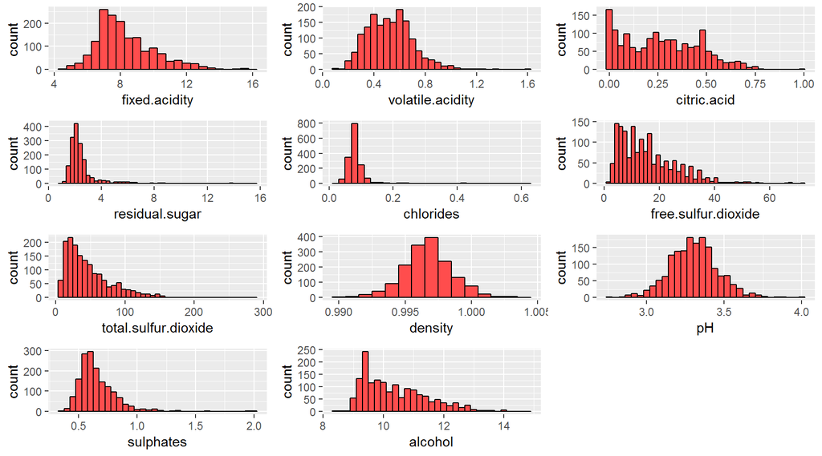

**Display the quailty grades**

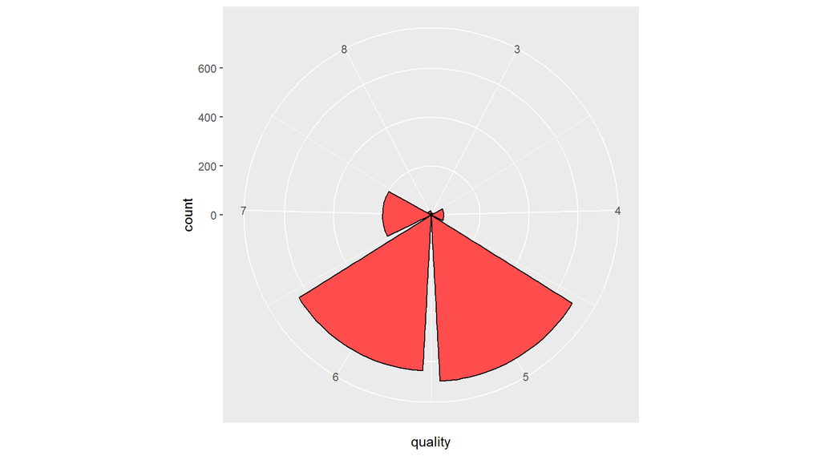

**We can see that most of the quality rating given were 5 and 6**

# Univariate Analysis

### What are the main features of interest in our dataset?

**First: Analysing quality is our aim**

**Second: Display correlation table to decide the interested features**

```
##                      fixed.acidity volatile.acidity citric.acid
## fixed.acidity                1.000           -0.256       0.672
## volatile.acidity            -0.256            1.000      -0.552
## citric.acid                  0.672           -0.552       1.000
## residual.sugar               0.115            0.002       0.144
## chlorides                    0.094            0.061       0.204
## free.sulfur.dioxide         -0.154           -0.011      -0.061
## total.sulfur.dioxide        -0.113            0.076       0.036
## density                      0.668            0.022       0.365
## pH                          -0.683            0.235      -0.542
## sulphates                    0.183           -0.261       0.313
## alcohol                     -0.062           -0.202       0.110
## quality                      0.124           -0.391       0.226
##                      residual.sugar chlorides free.sulfur.dioxide
## fixed.acidity                 0.115     0.094              -0.154
## volatile.acidity              0.002     0.061              -0.011
## citric.acid                   0.144     0.204              -0.061
## residual.sugar                1.000     0.056               0.187
## chlorides                     0.056     1.000               0.006
## free.sulfur.dioxide           0.187     0.006               1.000
## total.sulfur.dioxide          0.203     0.047               0.668
## density                       0.355     0.201              -0.022
## pH                           -0.086    -0.265               0.070
## sulphates                     0.006     0.371               0.052
## alcohol                       0.042    -0.221              -0.069
## quality                       0.014    -0.129              -0.051
##                      total.sulfur.dioxide density     pH sulphates alcohol
## fixed.acidity                      -0.113   0.668 -0.683     0.183  -0.062
## volatile.acidity                    0.076   0.022  0.235    -0.261  -0.202
## citric.acid                         0.036   0.365 -0.542     0.313   0.110
## residual.sugar                      0.203   0.355 -0.086     0.006   0.042
## chlorides                           0.047   0.201 -0.265     0.371  -0.221
## free.sulfur.dioxide                 0.668  -0.022  0.070     0.052  -0.069
## total.sulfur.dioxide                1.000   0.071 -0.066     0.043  -0.206
## density                             0.071   1.000 -0.342     0.149  -0.496
## pH                                 -0.066  -0.342  1.000    -0.197   0.206
## sulphates                           0.043   0.149 -0.197     1.000   0.094
## alcohol                            -0.206  -0.496  0.206     0.094   1.000
## quality                            -0.185  -0.175 -0.058     0.251   0.476
##                      quality
## fixed.acidity          0.124
## volatile.acidity      -0.391
## citric.acid            0.226
## residual.sugar         0.014
## chlorides             -0.129
## free.sulfur.dioxide   -0.051
## total.sulfur.dioxide  -0.185
## density               -0.175
## pH                    -0.058
## sulphates              0.251
## alcohol                0.476
## quality                1.000
```

1. Alcohol level has good impact on quality.
2. density aslo could affect the alcohol.
3. fixed acidity has strong positive relation with density.
4. pH has strong negitive relation with fixed acidity & citric.acid.

### Other feature in the dataset that will help support our investigation:

- As per the attribution description of density: “density of water is close to that of water depending on the percent alcohol and sugar content” so, I will consider residual sugar in the investigation.
- Strong relationship has been found between free.sulfur.dioxide and total.sulfur.dioxide which is logical.

### Creating new variables from existing variables in the dataset:

- According to our interests in the above features, new variable will be created to support our investigation:
1. since most of gardes given in 5 & 6 and maximum rate is 8, i will set defferent gardes for each one as follow: poor<=4, med_quality=5, good=6, v.good>=7.

```
##
##   Poor Quality Medium quality   Good Quality         V.Good
##             63            681            638            217
```

2. alcohol levels will be set as per summary as follow: low<= 9.5, low<Medium<11.5, High>11.5

```
##
##    Low Medium   High
##    436    913    250
```

```
##
##    Low Sweet Medium Sweet   High Sweet
##          620          854          125
```

### Other investigations :

- Density were presented with cm and should be converted into dm to match the other attributes.

# Bivariate Plots Section

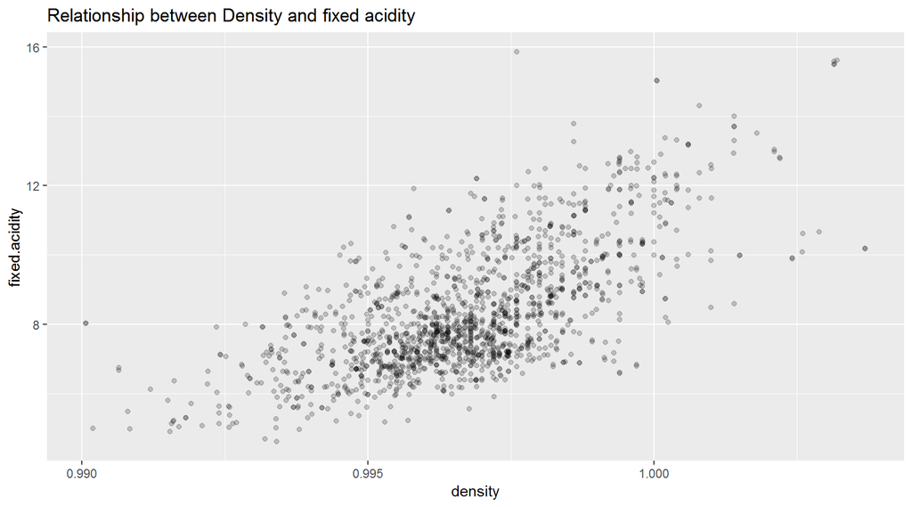

**Positive correlation with large variance**

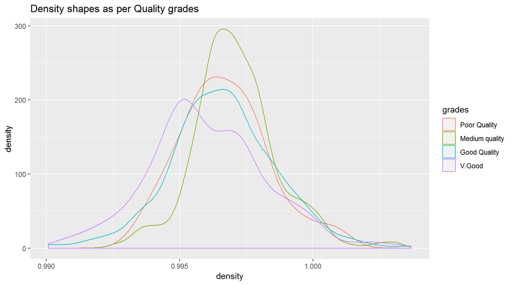

**No special shapes for each quality grade** **Between (0.990 - 0.991) only good and very good quality rating**

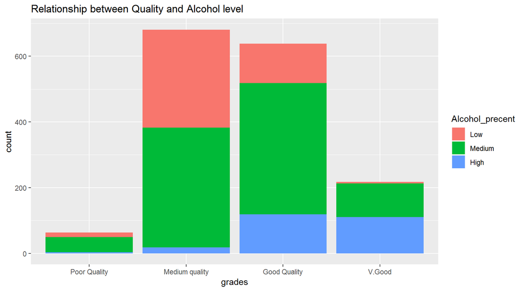

**Alcohol level is very important to determine quality rate as higher is better**

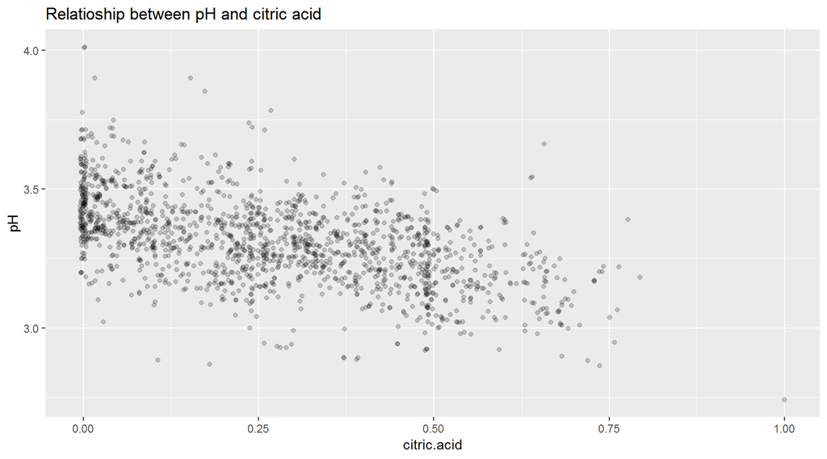

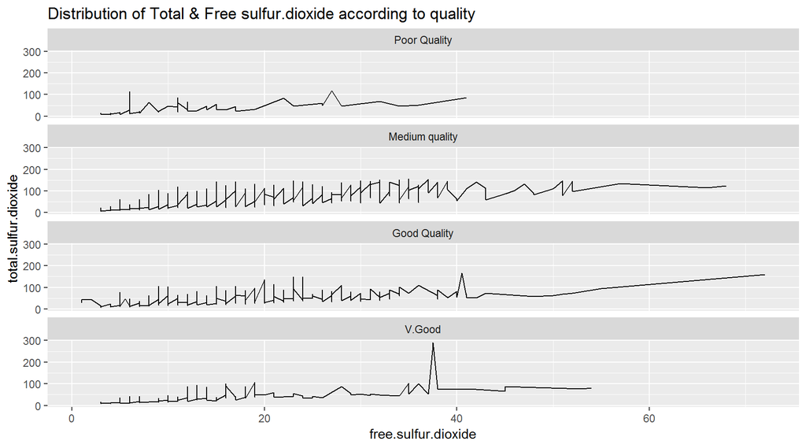

**Line chart shows defferent behavior according to quality grades**

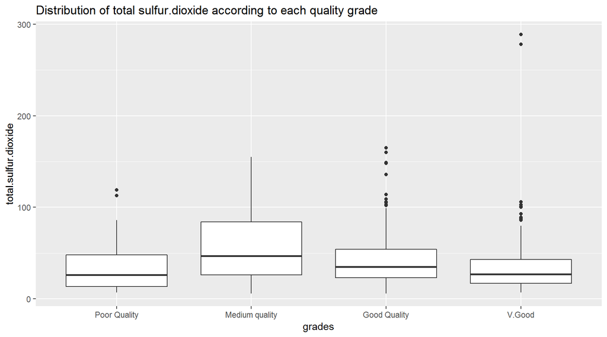

**Median and IQR are very similar to each other except medium qulaity has larger median and IQR, there are outliers values in good and v.good quality**

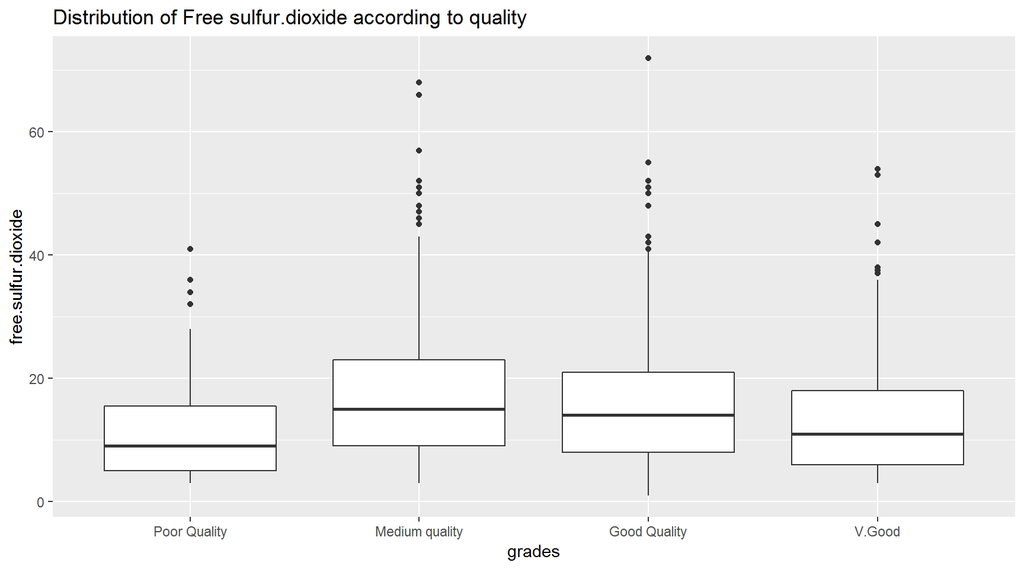

**No special range or average that would differentiate free sulfur dioxide according to quality, and I recognize outliers in each grades**

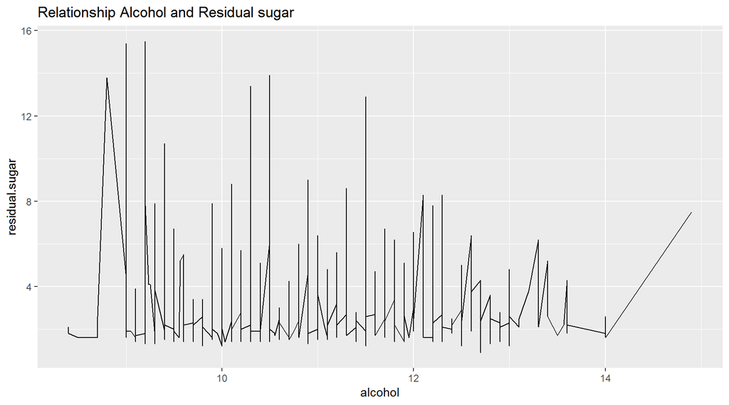

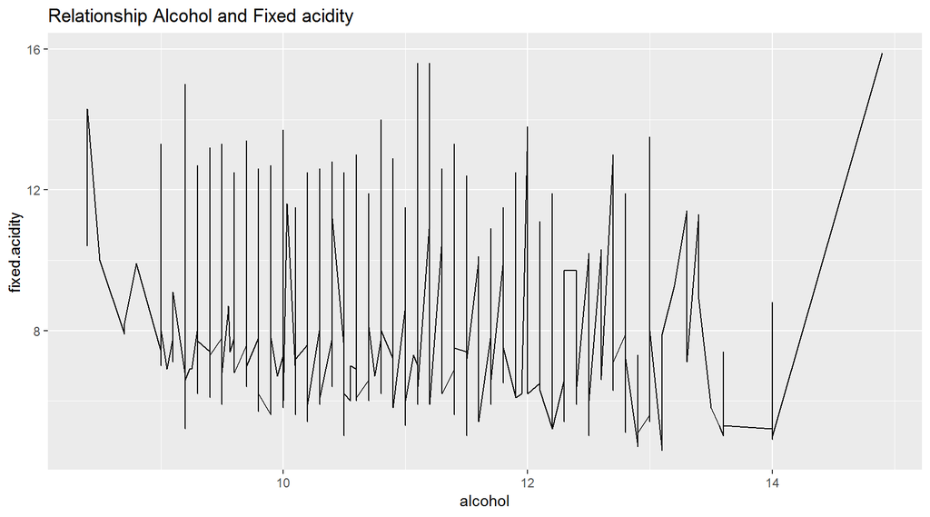

**Very fluctuate results and could not read useful information**

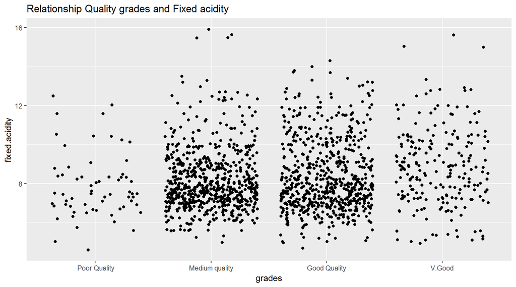

**Data are not clustered in specific range of fixed acidity that we could predict a good range to hit better quality**

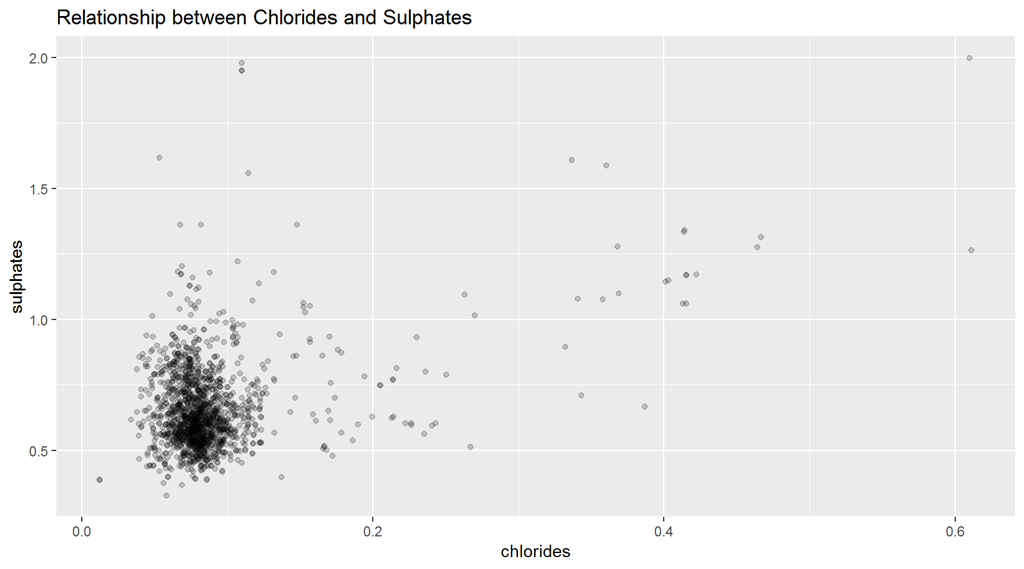

**Most of data clustered at around 0.1(chlorides) and below 1.0(sulphates) relationship indicate positive relationship.**

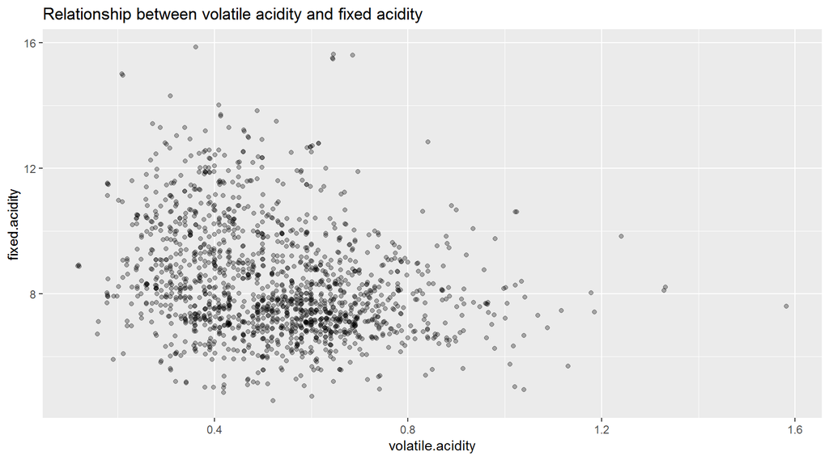

**Non linear relationship between volatile.acidity and fixed.acidity**

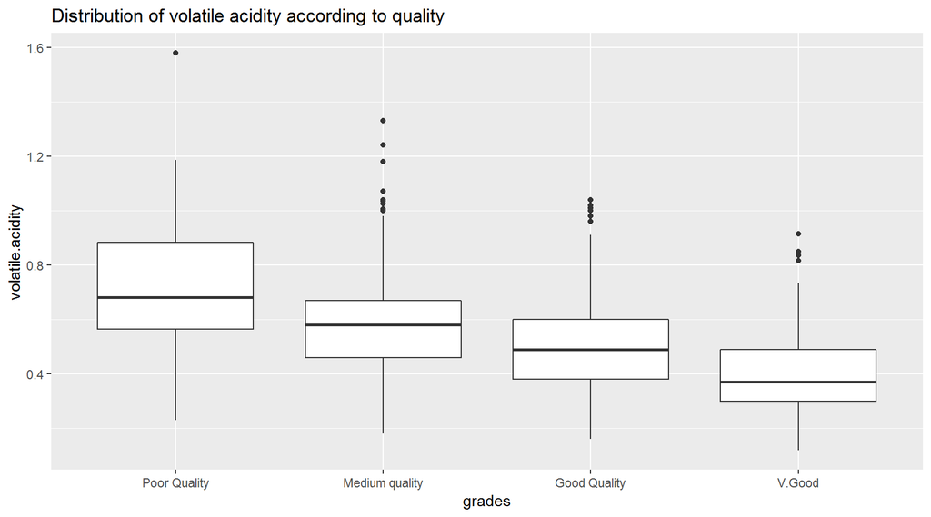

**Here I can negitive relationship between the quality and volatile acidity, as we need low volatile acidity to receive best rating**

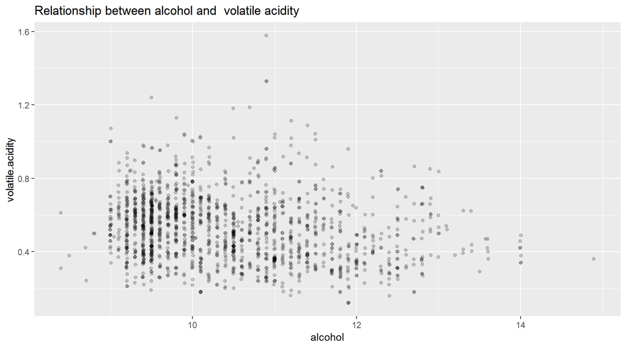

**Can not see direct relation between alcohol and volatile acidity althogh they could affect the quality as per pervious plot**

# Bivariate Analysis

### Relationships I observed in the above plots:

# Multivariate Plots Section

## Plot one:

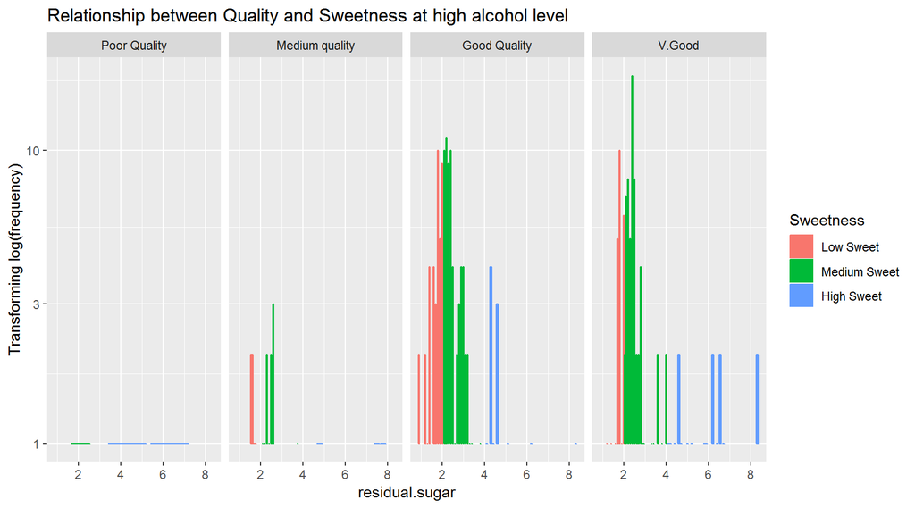

**At high alcohol level, medium sweet received best rating**

# Multivariate Analysis of Plot One

### Were there any interesting or surprising interactions between features?

Relation between alcohol and residual sugar: I found that medium sweet and low sweet wine has much better rating than high sweet wine at the high level alcohol(high alcohol level receive better rating as we mentioned before).

## Plot Two:

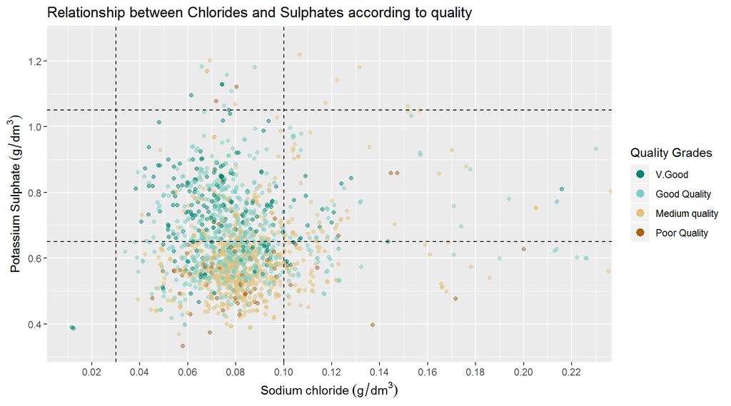

**Omitting 1% of top sulphates values and 2% of top chlorides values**

# Multivariate Analysis of Plot Two

### Very interesting relationship relationships I observed:

Relationship between chlorides and sulphates is positive but we need to look closely at the quality grades applied to it.

### Were there any interesting or surprising interactions between features?

Relation between chlorides and sulphates, we could find the best wine rating when chlorides is between 0.03-0.1 and sulphates between 0.65-1.05, as we found most of Very good and good rating in this range along with some medium quality rates.

# Final Plots and Summary

### Plot One

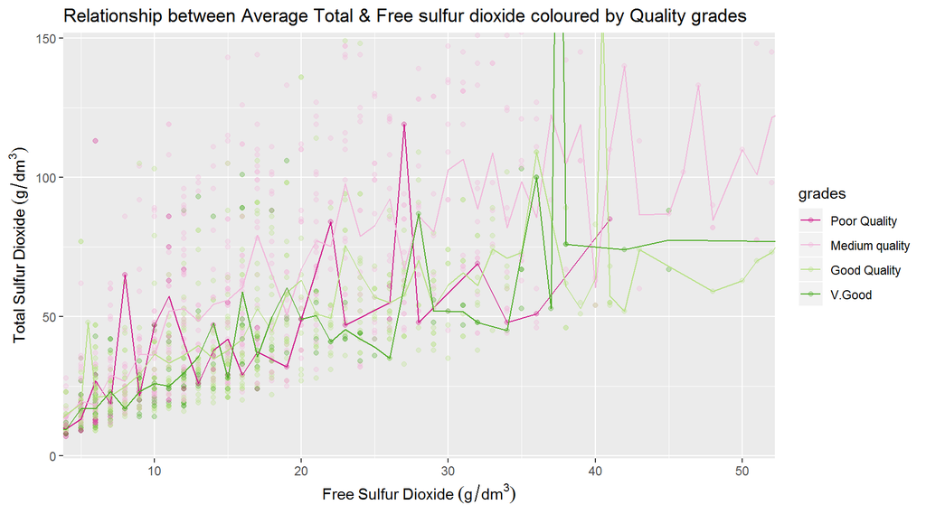

### Description One

- Relationship between Total & Free sulfur dioxide has been presented by average mean, I choose this plot because all the poor rating wine with free sulfur.dioxide of 40 and after 40 rating is meduim quality, good and very good.
- After (free sulfur.dioxide of 40) less total sulfur dioxide means better quality rating.

### Plot Two

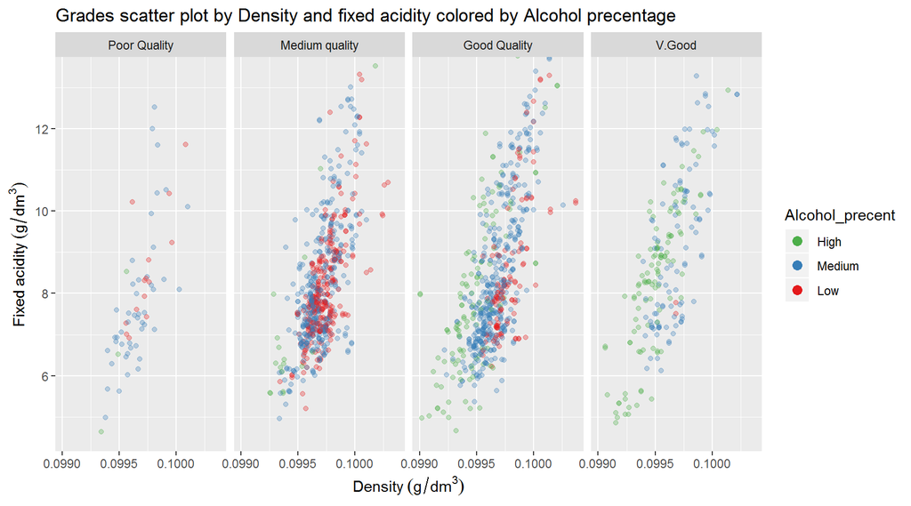

**As confirmed before high alcohol level receive best quality rate**

### Description Two

- Very interesting relationship between density and fixed.acidity as it is strong positive relationship, after converting density to dm and facet it to quality rating and coloured by alcohol levels I could not found evdince how fixed acidity and density affect the quality but i found that best rates were given to high and medium alcohol llevels.

### Plot Three

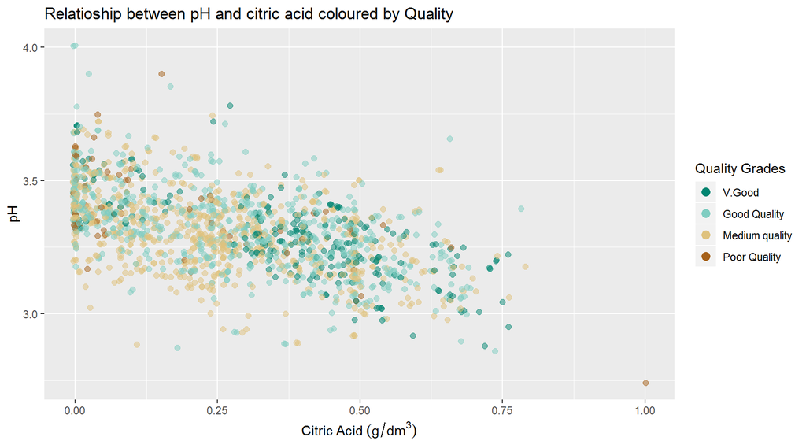

**Could extract the best level of Citric acid according to pH but it will not be 100% accurate**

### Description Three

# Reflection

- Data summary and correlation table is very helpful in beginning of the analysis, and I could use correlation matrix plot for more instant information.
- Some difficulties faced me during the analysis due to the lack of information about the variables as I should started reading more about the attributes and investigate more before starting the analysis.
- Using R in analysing Red Wine dataset was amazing and I was surperised how much it can tansfer the information into very clear and readable plot that could help a lot, example data that we collected from (Multivariate Analysis of Plot Two) we very helpful.
- Many plots does not help a lot to determin quality but others surprised me such as the sweetness should be low or medium for best quality.